title: “Chapter - 6: What to add and what not to add to Bayesian Models” output: html_document: number_sections: true — —

To summarize (straight from the book)-

> Multiple Regression is no oracle. It is logical, but the relationships it describes are *conditional associations*, not causal influences. Therefore, additional information, from outside the model, is needed to make sense of it. This chapter *presents* introductory examples *with simulations* to show some common frustations: multicollinearity, post-treatment bias, and collider bias. Soltions to these frustations can be organized under a coherent framework in which hypothetical causal relations among variables are analyzed to *locate* and cope with *confounding*. In all cases, causal models *discussed* exist outside the statistical model and can be difficult to test. However, it is possible to reach valid causal inferences in the absence of experiments. This is good news, because we often cannot perform experiments, both for practical and ethical reasons.

Allright, let’s dive right in, here’s the agenda - 1. (Exciting!) Simulate few examples to show common confounds (this word, will make itself clear as we move along) 2. (Meh ..) Go back to theory and develop it a bit 3. (Very Exciting!) Take the thory, apply to examples in 1. and make sense of it

# Example 1 - Why are news articles that sound sensational less likely to be trustworthy?

Often we read newspapers and observe the above effect, same with reading Scientific journals or even reading lists of projects which have been awarded Scientific grants. Our question is - “Do news articles with higher sensational content less likely to be factually correct?” The answer is - “The data does not justify this observation as this effect can be observed even if all news articles are equally likly to be sensational and trustworthy”. Let’s simulate and see

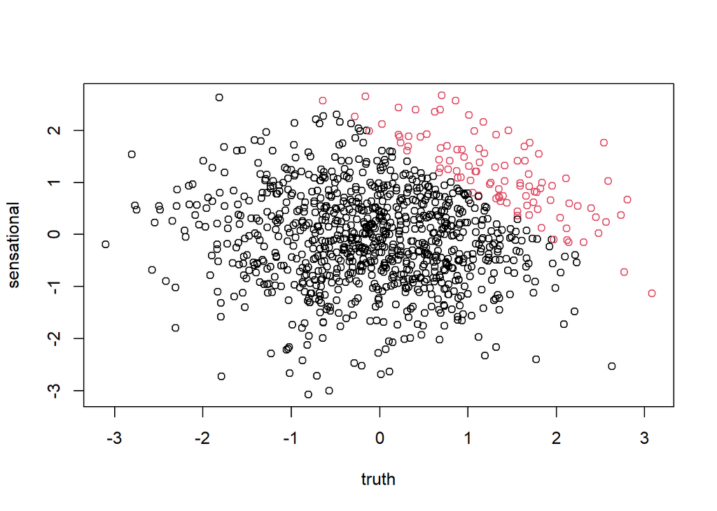

```r
# Simulate n articles with independent truth and sensational content.
n = 1000

truth <- rnorm(n)
sensational <- rnorm(n)

# Editor chooses the top 10% to publish - combining both the scores
score <- truth+sensational
chosen <- score > quantile(score, prob=0.9)
plot(x = truth, y = sensational, col = (chosen+3)/2)
```

```r
cor(truth[chosen], sensational[chosen])
```

```
## [1] -0.7762022
```

So, the red points, clearly show a negative correlation - this does not mean the news articles which are trustworthy are not sensational, but rather this is *after* we select the news articles that this is observed. This is called as *BERKSON’S PARADOX* or more helpfully as *selection-distortion* effect.

# Example 2: Multicollinear legs - IS length of legs a strong predictor of a person’s height?

If you think Yes, then go through below -

```r
library(rethinking)
```

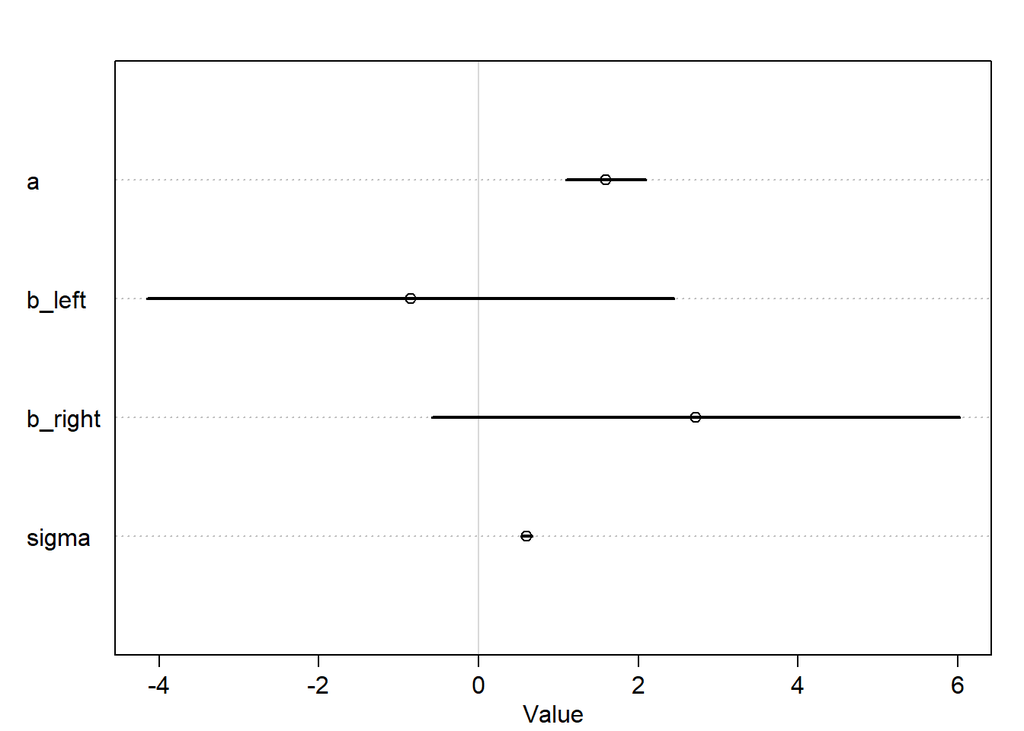

```r
N<-100
height <- rnorm(N, 10, 2) # simulate height
legs_proportion <- runif(N, 0.4, 0.5) # Assign proportion of a person's leg length as from a uniform distribution
left_leg <- legs_proportion*height + rnorm(N, 0, 0.02) # Add a developmental process tweak to leg length of about 1/50th of the height
right_leg <- legs_proportion*height + rnorm(N, 0, 0.02)

d <- data.frame(height, left_leg, right_leg)

# Build a model to see how leg length affects height of a person

m6.1 <- quap(alist(
  height ~ dnorm(mu, sigma),
  mu <- a + b_left*left_leg + b_right*right_leg,
  a ~ dnorm(10, 100), # A vastly flat prior so our observation is not dented by choice of prior
  b_left ~ dnorm(2, 10), # We expect positive effect of leg length on height but not too sure about it's range
  b_right ~ dnorm(2, 10),
  sigma ~ dexp(1)),
 data = d)

plot(precis(m6.1))
```

a_left and a_right have huge uncertainity in their values! What explains this? Does this mean our model does not have a strong view on their importance on the height of the person? Let’s also try the model this time with only one leg

```r
m6.2 <- quap(alist(
  height ~ dnorm(mu, sigma),
  mu <- a + b_left*left_leg,
  a ~ dnorm(10, 100), # A vastly flat prior so our observation is not dented by choice of prior
  b_left ~ dnorm(2, 10), # We expect positive effect of leg length on height but not too sure about it's range
  sigma ~ dexp(1)),
 data = d)
```

```
## Caution, model may not have converged.
```

```
## Code 1: Maximum iterations reached.
```

```r
precis(m6.2)
```

```
##             mean        sd      5.5%     94.5%
## a      115.85661 17.117052  88.50025 143.21296
## b_left -21.04040  3.663858 -26.89596 -15.18485
## sigma   55.09167       NaN       NaN       NaN
```

The question we ask our model when doing multiple regression is not “How important is left leg’s length for predicting height?” but “How much additional information does having left leg’s length provide given we already know right leg’s length?” The problme is not in the model, but in the question we are asking.

To look at another way, let’s look at the posterior samples of b_left and b_right and see.

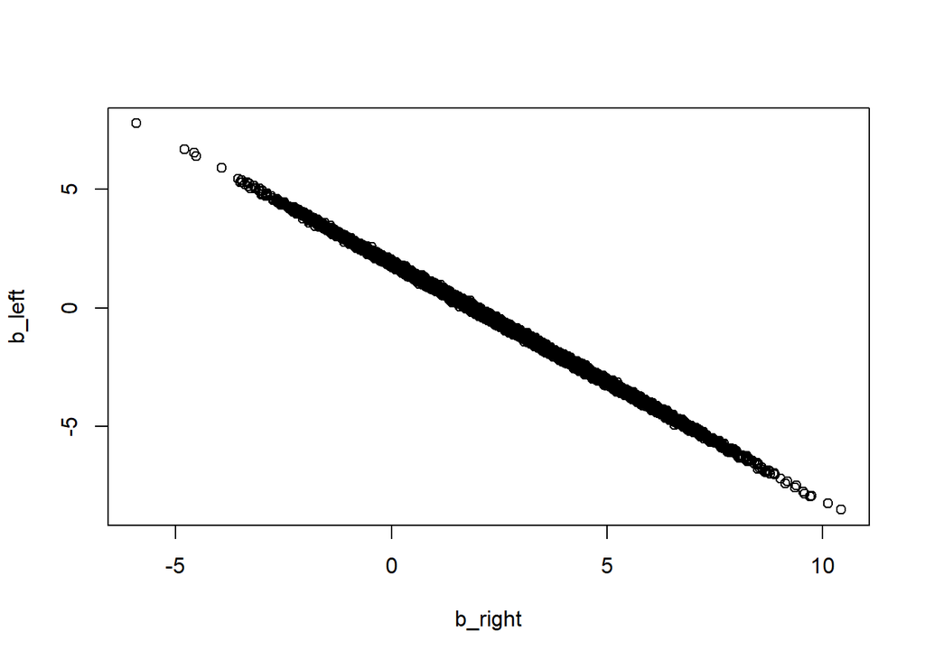

```r
post <- extract.samples(m6.1)
plot(b_left ~ b_right, post)
```

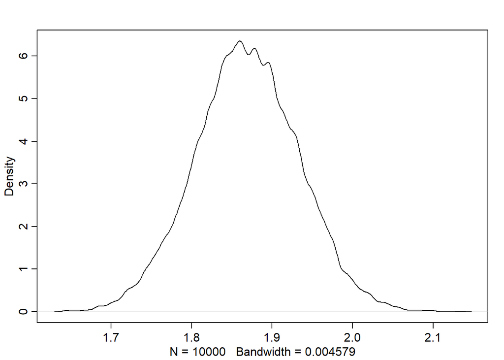

```r
dens(post$b_left+post$b_right)
```

As is clear, the joint distribution of b_left and b_right does show certainity, it shows extremely high correlation.

Another way to look at it is that our model says (assuming both left and right leg are perfectly correlated, implying they are both equal in this case to left_length) -  
mean of height = a + b_left x left_length + b_right x right_length $\sim$ a + (b_left + b_right) x left_length

Hence, our linear regression is essentially learning a joint distribution as shown in second plot above.

# Example 3 - Multicollinear Milk

Let’s look at a more advanced and practical situation now - Let’s look at milk composition of primates, specifically, how the energy density of the milk relates to it’s fat content and lactose content. Let’s build 3 models - one for energy ~ fat, energy ~ lactose, energy ~ fat + lactose

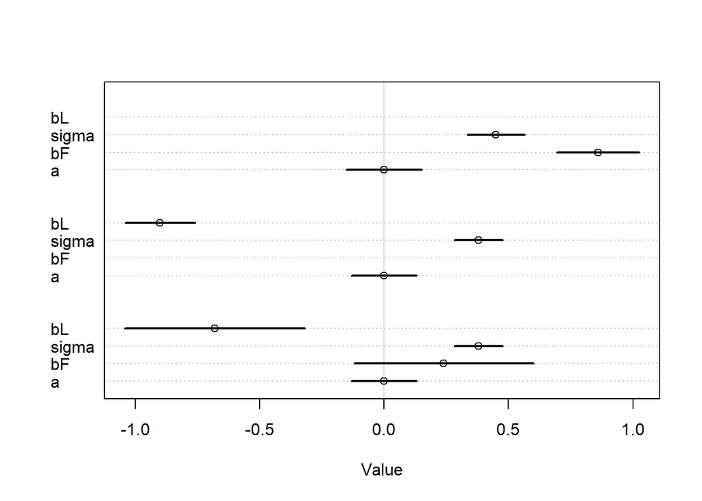

```r
library(rethinking)
data(milk)
d <- milk
# Standardize
d$K <- scale(d$kcal.per.g)
d$F <- scale(d$perc.fat)
d$L <- scale(d$perc.lactose)

# energy ~ fat
m6.3 <- quap(
  alist(
    K ~ dnorm(mu, sigma),
    mu <- a + bF * F,
    a ~ dnorm(0, 0.2),
    bF ~ dnorm(0, 0.5),
    sigma ~ dexp(1)
  ),
  data=d
)


# energy ~ lactose
m6.4 <- quap(
  alist(
    K ~ dnorm(mu, sigma),
    mu <- a + bL * L,
    a ~ dnorm(0, 0.2),
    bL ~ dnorm(0, 0.5),
    sigma ~ dexp(1)
  ),
  data=d
)


# energy ~ lactose + fat
m6.5 <- quap(
  alist(
    K ~ dnorm(mu, sigma),
    mu <- a + bF * F + bL * L,
    a ~ dnorm(0, 0.2),
    bL ~ dnorm(0, 0.5),
    bF ~ dnorm(0, 0.5),
    sigma ~ dexp(1)
  ),
  data=d
)

plot(coeftab(m6.3, m6.4, m6.5, rotate = TRUE)) # plots models on y axis in that order from top to bottom
```

Observations - 1. bF and bL have much tighter estimates in their original model than in the combined model - This is because they have a joint axis of variation along which they both can take a large range of values in the combined model 2. Combined model assigns much lower estimate to bF than in it’s original model - this means one cannot simply say by looking at combined model “Fat content in milk does not explain it’s energy content”, instead we should say “Once the model knows the LActose content of milk it’s fat content is relatively less important”

Now, how do we figure this out without actually building the models? We will look at a much more general and sophisticated theory shortly but for now, let’s look at the pairwise correlations -

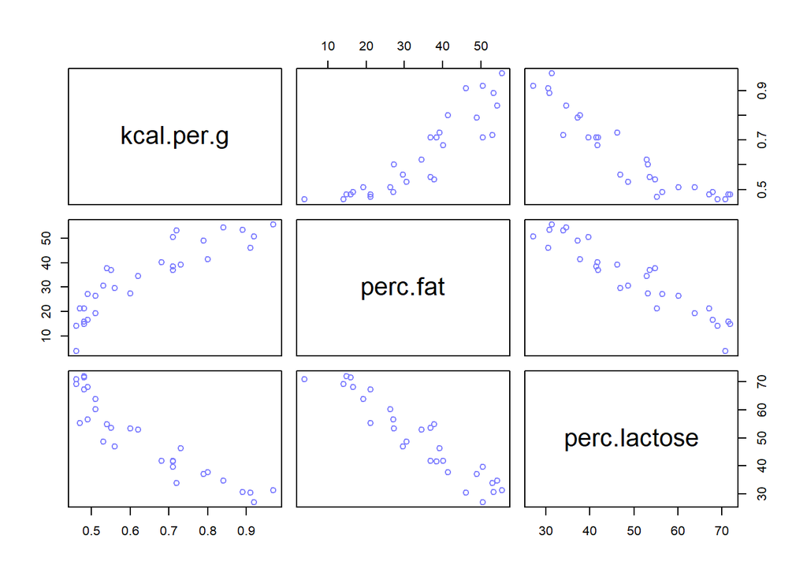

```r
pairs(~kcal.per.g + perc.fat + perc.lactose, data=d, col = rangi2)
```

The middle right plot clearly shows the huge correlation between Fat and Lactose, it’s this correlation which is confounding as the fat and energy have an otherwise strong correlation, it’s just that lactose and energy have a stronger one.

So, what should we conclude from this example?

> In Scientific literature (*or even in professional Data Scientist world*), there are several dodgy ways of coping with multicollinearity. Few of these take a causal perspective. … In some cases people just inspect the pairwise correlations and drop the highly correlated predictors. This is a mistake. Pairwise correlations are not the problem, it’s the conditional associations that matter. The right thing (not easy) depends on what is causing the collinearity. Associations within the data are not enough to tell us what to do, what would help is to have a causal model.

```r
 library(dagitty)
```

```
## Plot coordinates for graph not supplied! Generating coordinates, see ?coordinates for how to set your own.
```

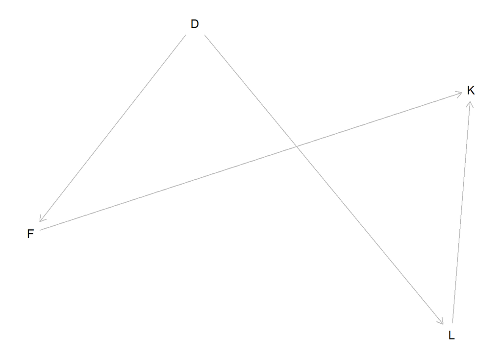

```r
dag_milk <- dagitty("dag {
                      D [unobserved]
                      L <- D -> F
                      L -> K <- F
}")
plot(dag_milk)
```

The problem of multicollinearity is a member of a family of problems known as NON-IDENTIFIABILITY which says that the structure of the problem and the data do not make it possible to estimate the parameter’s value. In Bayesian analysis, the problem is nto as much as non-identifiability as we still have the parameter estimates but one of weak identifiability as the estimates are not very confident.

# Post-treatment bias - Is my Anti Fungal treatment working?

Suppose you gro tomatoes but unfortunately have started seeing some fungus which you think is impacting their height, you want to know if using some fungicide will help their growth or not. Being a true scientist, you setup an experiment in a greenhouse by growing the tomato plants on 2 kinds of beds - one has been treated with fungicides and the other is not. You then measure height of plants at germination and 5 weeks later - measuring the initial height, final height, treatment or not and presence of fungus at the end.

You know want to find if your treatment is causing the height of plants to increase or not. Let’s simulate some data to get going

```r
# Number of plants
N <- 100

# Initial heights
h0 <- rnorm(N, 10, 2)

# assign treatment and simulate fungus and growth
treatment <- rep(0:1, each=N/2)
fungus <- rbinom(N, size=1, prob=0.5 - treatment * 0.4)
h1 <- h0 + rnorm(N, 5-3*fungus)

d <- data.frame(h0, h1, treatment, fungus)
precis(d)
```

```
##               mean        sd     5.5%    94.5%
## h0         9.70773 2.4644098 6.201763 13.53822
## h1        13.57768 3.1231795 7.880151 18.20441
## treatment  0.50000 0.5025189 0.000000  1.00000
## fungus     0.35000 0.4793725 0.000000  1.00000
##                                                                                                                  histogram
## h0        ▁▃▅▃▇▅▃▂▂▁▁▁▁▁
## h1                                                ▁▁▁▃▇▃▃▁▁
## treatment                                 ▇▁▁▁▁▁▁▁▁▇
## fungus                                    ▇▁▁▁▁▁▁▁▁▃
```

Now let’s build our model

```r
m6.6 <- quap(
  alist(
    h1 <- dnorm(mu, sigma),
    mu <- h0 * p,
    p ~ a + bt * treatment + bf * fungus,
    a ~ dlnorm(0, 0.25),
    bt ~ dnorm(0, 0.5),
    bf ~ dnorm(0, 0.5),
    sigma ~ dexp(1)
  ),
  data = d
)
precis(m6.6)
```

```
##                mean         sd        5.5%      94.5%
## a      1.4603224893 0.03156696  1.40987239  1.5107726
## bt     0.0007751778 0.03586145 -0.05653834  0.0580887
## bf    -0.2521782986 0.03797265 -0.31286593 -0.1914907
## sigma  1.5117264575 0.10573757  1.34273740  1.6807155
```

So the model above says our treatment has not impact on plant height at all! :(  
Despair not, this is just a case of post treatment bias as when we included the presence of fungus in our model, we eliminated any need for the model to know the treatment as fungus alone explains all the height. This is becasue fungus really is a *post-treatment* variable and hence should not be included if we want to measure the impact of our treatment on plant height. Let’s do another turn, without the fungus -

```r
m6.7 <- quap(
  alist(
    h1 <- dnorm(mu, sigma),
    mu <- h0 * p,
    p ~ a + bt * treatment,
    a ~ dlnorm(0, 0.25),
    bt ~ dnorm(0, 0.5),
    sigma ~ dexp(1)
  ),
  data = d
)
precis(m6.7)
```

```
##            mean        sd       5.5%     94.5%
## a     1.3081945 0.0261771 1.26635845 1.3500306
## bt    0.1301144 0.0361981 0.07226281 0.1879659
## sigma 1.8170739 0.1267211 1.61454914 2.0195987
```

This model shows a clear positive impact of treatment on plant height! Yay! our treatment works!

In terms of the causal graph -

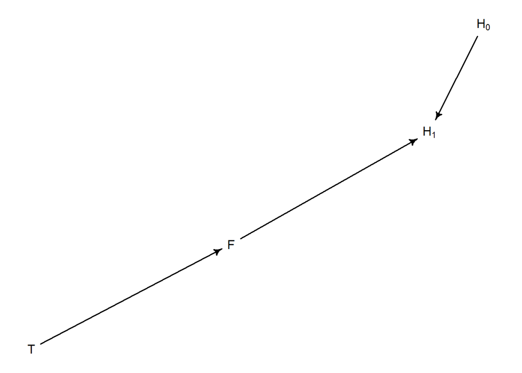

```r
plant_dag <- dagitty("dag {
                     H_0 -> H_1
                     F -> H_1
                     T -> F
}")
drawdag(plant_dag)
```

The moment we condition on F (i.e., include F in our model), we block the path from T to H1, that’s what happened in our first model. Techincally speaking, F induces a *D-SEPARATION* (D for directional). Thus, H1 is d-separated from T when we condition on F.

It’s not just that adding a variable can block the association, it can also cause an association where there is None, consider following DAG -

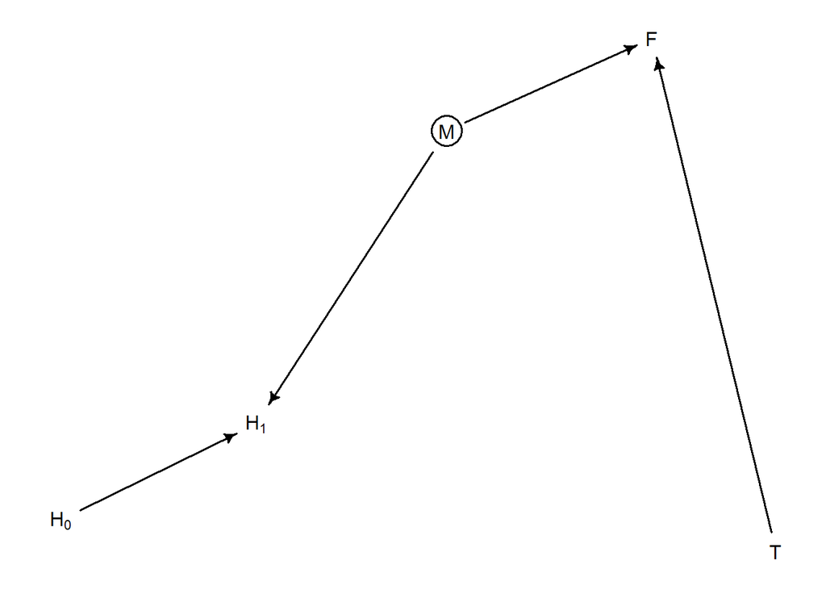

```r
plant_dag <- dagitty("dag {
                     M [unobserved]
                     H_0 -> H_1
                     M -> F
                     M -> H_1
                     T -> F
}")
drawdag(plant_dag)
```

In above case, M is a hidden variable (could be Moisture, for e.g.) and T is not really associated with H1, neither is F (maybe this fungus species does not bother the plant), however, if we did add F to our model, we would observe an association between T and H1, because including F, provides indirect info about M which in turn really does impact the plant height.

This brings us to our next example, one of COLLIDER-BIAS

# Collider Bias - Is Happiness a function of Age ?

Let’s move on to a more interesting (and provocative!) question. Why do we focus so much on simulations? Well, it allows us to control the relationships in our example and if a procedure can’t figure out truth in a simulated example, it can’t in a real example as well.

1. Each year, 20 people are born with uniformly simulated happiness values
2. Each year, person ages by 1 year, happiness does not change
3. At age 18, individuals can become married. The odds of marriage each year are proportional to an individual’s happiness
4. Once married, stay married
5. After age 65, they leave the sample (move to Bahamas!)

```r
library(rethinking)
d <- sim_happiness(seed=1977, N_years=1000)
precis(d)
```

```
##                    mean        sd      5.5%     94.5%
## age        3.300000e+01 18.768883  4.000000 62.000000
## married    3.007692e-01  0.458769  0.000000  1.000000
## happiness -1.000070e-16  1.214421 -1.789474  1.789474
##                                                                                                          histogram
## age       ▇▇▇▇▇▇▇▇▇▇▇▇▇
## married                           ▇▁▁▁▁▁▁▁▁▃
## happiness                                         ▇▅▇▅▅▇▅▇
```

```r
head(d)
```

```
##   age married  happiness
## 1  65       0 -2.0000000
## 2  65       0 -1.7894737
## 3  65       1 -1.5789474
## 4  65       0 -1.3684211
## 5  65       0 -1.1578947
## 6  65       0 -0.9473684
```

So we are viewing a Snapshot of this universe at year 1000 with about 1300 people. Why 1300? That’s 20x65.

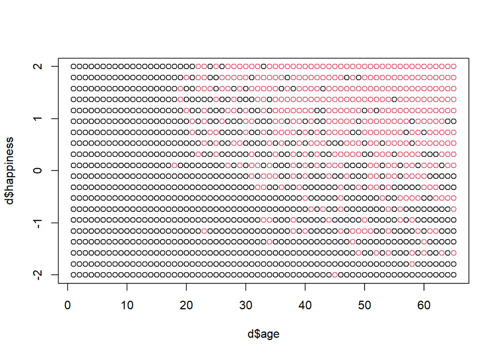

```r
plot(d$age, d$happiness, col=d$married+1)
```

Note that if we plotted only the red points (married folks), it would seem as if happiness decreases with age, which is clearly not the case in our simulation, this is an example of Confounding.

Anyways, you come across this data and want to analyze if Age impacts happiness, you reason that Marriage may be an important factor and try to control for it. The linear model is

$$\mu_i = \alpha_{MID[i]} + \beta_A A_i$$